# Chapter 2: Statistical Learning

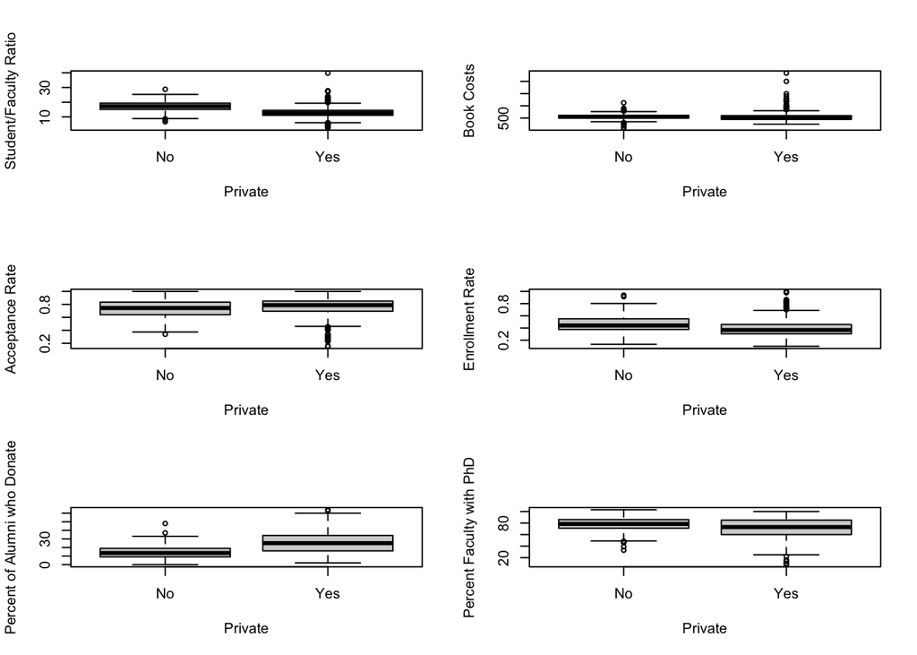

   ```r
   par(mfrow=c(3,2))
   plot(Private, S.F.Ratio, xlab="Private", ylab="Student/Faculty Ratio")
   plot(Private, Books, xlab="Private", ylab="Book Costs")
   plot(Private, AcceptRate, xlab="Private", ylab="Acceptance Rate")
   plot(Private, EnrollRate, xlab="Private", ylab="Enrollment Rate")
   plot(Private, perc.alumni, xlab="Private", ylab="Percent of Alumni who Donate")
   plot(Private, PhD, xlab="Private", ylab="Percent Faculty with PhD")
   ```

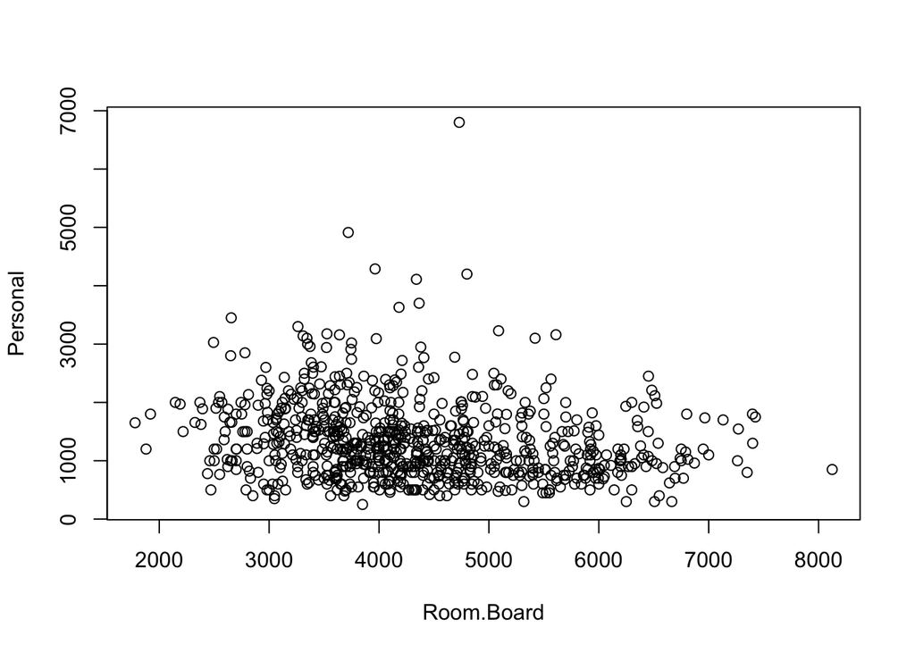

   ```r
   plot(Room.Board, Personal)
   ```

   ```r
   cor(Room.Board, Personal)
   ```

   ```
   ## [1] -0.1994282
   ```

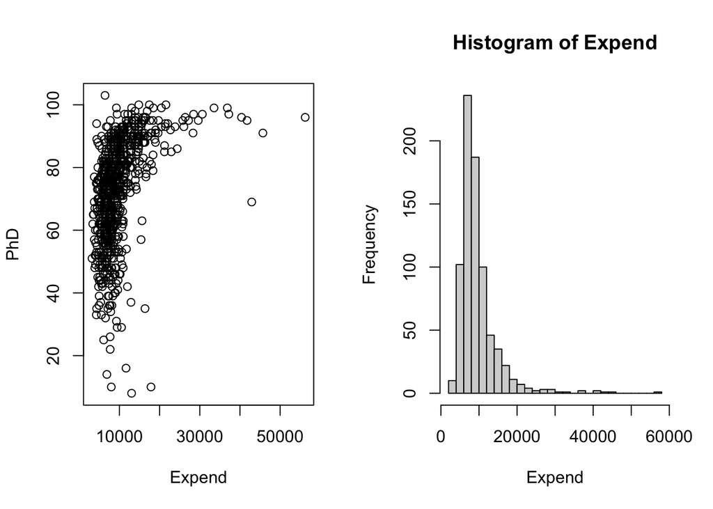

   ```r
   par(mfrow=c(1,2))
   plot(Expend, PhD)
   hist(Expend, breaks=20)
   ```

   ```r
   median(Expend)
   ```

   ```
   ## [1] 8377
   ```

9. This exercise involves the `Auto` data set. Make sure that the missing values have been removed from the data.

   ```r
   Auto <- read.table("Auto.data", header = T, na.strings = "?", stringsAsFactors = T)
   Auto <- na.omit(Auto)
   attach(Auto)
   View(Auto)
   ```

   1. Which of the predictors are quantitative, and which are qualitative?

      *Quantitative: mpg, displacement, horsepower, weight, acceleration. Qualitative: cylinders (there are few unique values), year (depends on context), origin, name*
   2. What is the range of each quantitative predictor?

   ```r
   quant_cols <- c("mpg", "displacement", "horsepower", "weight", "acceleration")
   apply(Auto[quant_cols], 2, range)
   ```

   ```
   ##       mpg displacement horsepower weight acceleration
   ## [1,]  9.0           68         46   1613          8.0
   ## [2,] 46.6          455        230   5140         24.8
   ```

   3. What is the mean and standard deviation of each quantitative predictor?

   ```r
   colMeans(Auto[quant_cols])
   ```

   ```
   ##          mpg displacement   horsepower       weight acceleration
   ##     23.44592    194.41199    104.46939   2977.58418     15.54133
   ```

   ```r
   apply(Auto[quant_cols], 2, sd)
   ```

   ```
   ##          mpg displacement   horsepower       weight acceleration
   ##     7.805007   104.644004    38.491160   849.402560     2.758864
   ```

   4. Now remove the 10th through 85th observations. What is the range, mean, and standard devation of each predictor in the subset of data that remains?

   ```r
   newAuto <- Auto[-10:-85, ]
   apply(newAuto[quant_cols], 2, range)
   ```

   ```
   ##       mpg displacement horsepower weight acceleration
   ## [1,] 11.0           68         46   1649          8.5
   ## [2,] 46.6          455        230   4997         24.8
   ```

   ```r
   colMeans(newAuto[quant_cols])
   ```

   ```
   ##          mpg displacement   horsepower       weight acceleration
   ##     24.40443    187.24051    100.72152   2935.97152     15.72690
   ```

   ```r
   apply(newAuto[quant_cols], 2, sd)
   ```

   ```
   ##          mpg displacement   horsepower       weight acceleration
   ##     7.867283    99.678367    35.708853   811.300208     2.693721
   ```

   5. Using the full dat set, investigate the predictors graphically, using scatterplots or other tools of your choice. Create some plots highlighting the relationships among predictors. Comment on your findings.

   ```r
   cat_cols <- c("cylinders", "year", "origin")
   Auto[cat_cols] <- lapply(Auto[cat_cols], as.factor)
   ```

   ```r
   attach(Auto)
   ```

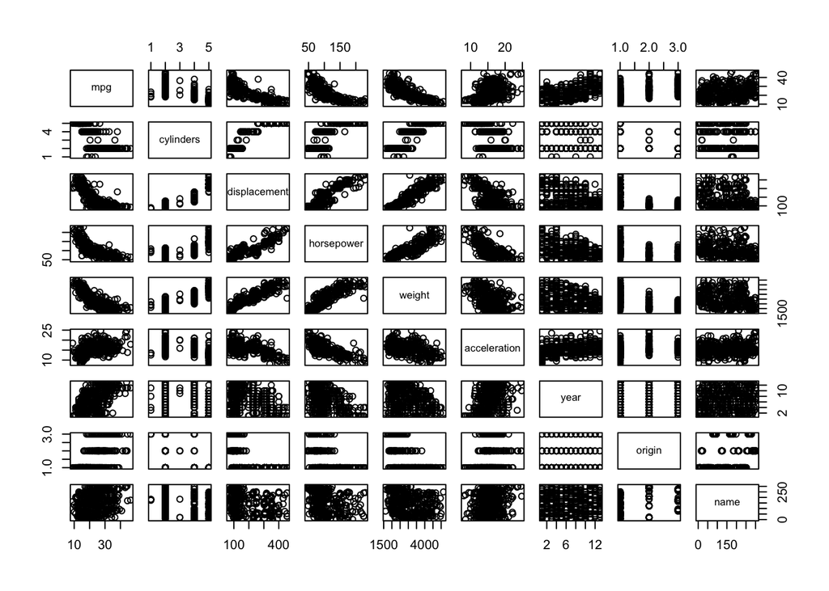

   ```r
   pairs(Auto)
   ```

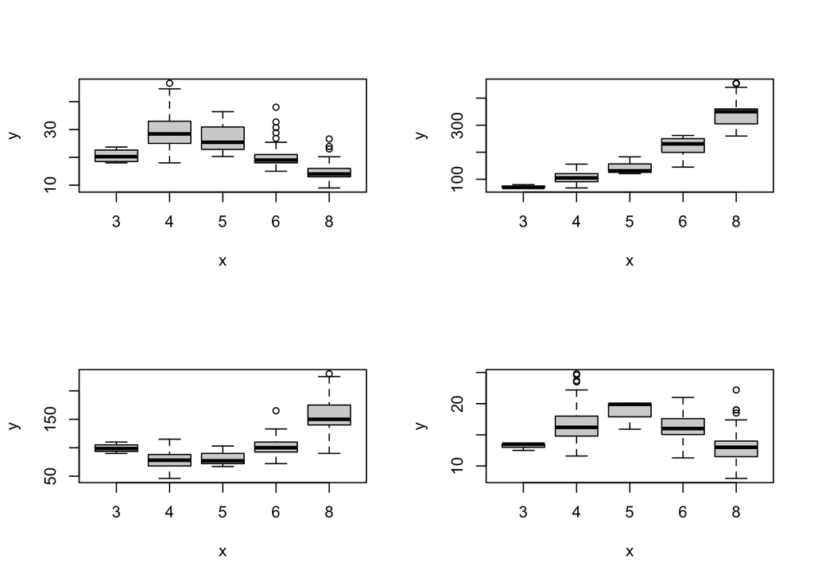

   ```r
   par(mfrow = c(2, 2))
   plot(cylinders, mpg)
   plot(cylinders, displacement)
   plot(cylinders, horsepower)
   plot(cylinders, acceleration)
   ```

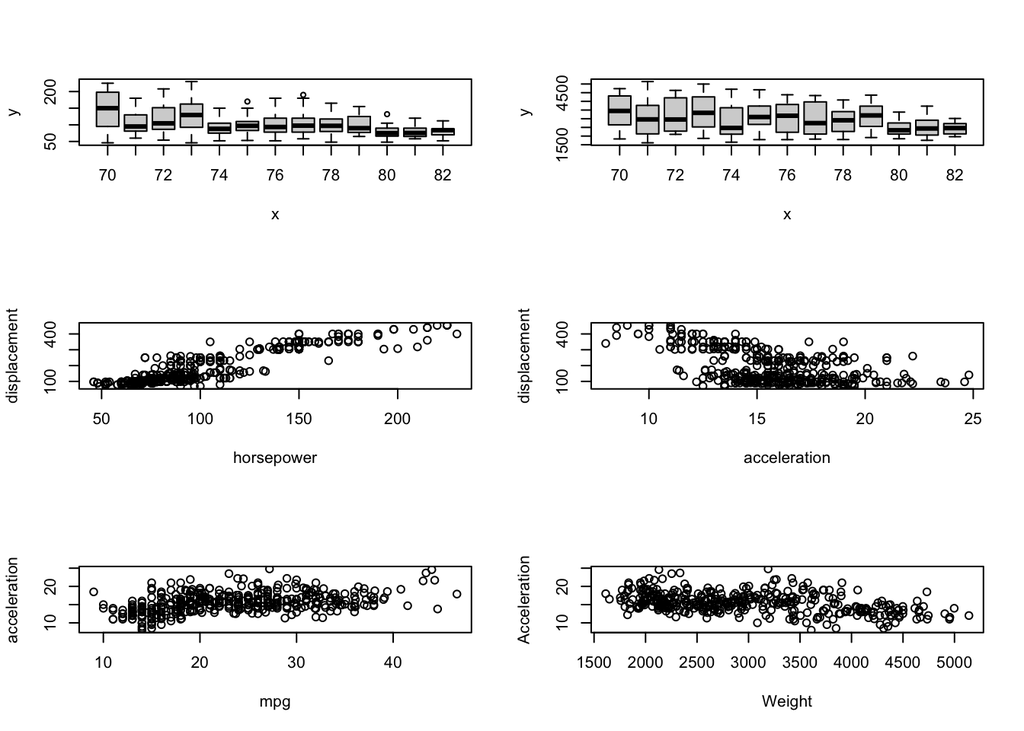

   ```r
   par(mfrow = c(3, 2))
   plot(year, horsepower)
   plot(year, weight)
   plot(horsepower, displacement)
   plot(acceleration, displacement)
   plot(mpg, acceleration)
   plot(weight, acceleration, xlab="Weight", ylab="Acceleration")
   ```

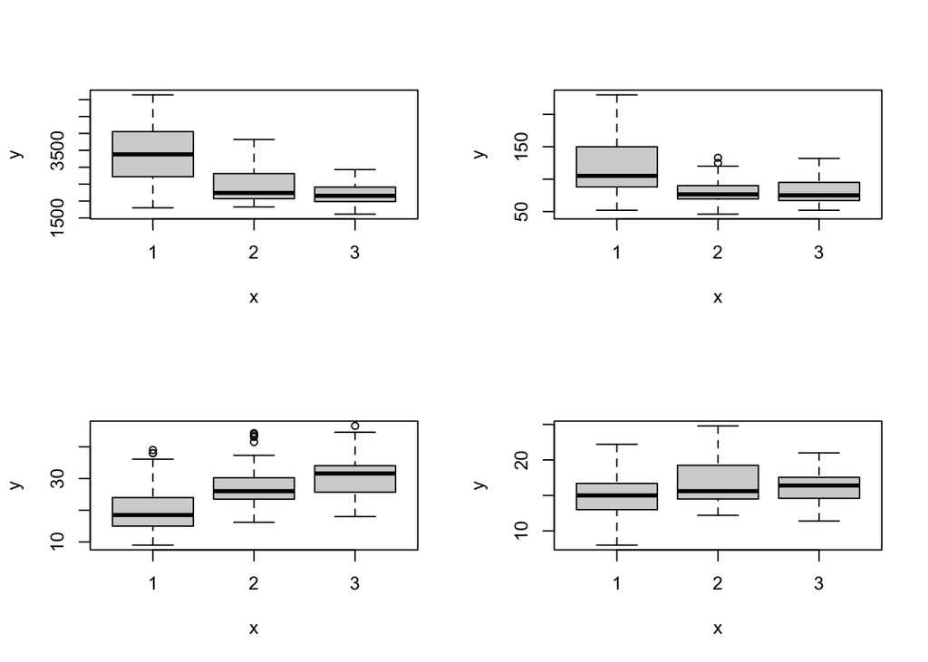

   ```r
   par(mfrow = c(2, 2))
   plot(origin, weight)
   plot(origin, horsepower)
   plot(origin, mpg)
   plot(origin, acceleration)
   ```

   ```r
   cor(displacement, horsepower)
   ```

   ```
   ## [1] 0.897257
   ```

   ```r
   cor(weight, mpg)
   ```

   ```
   ## [1] -0.8322442
   ```

   ```r
   cor(displacement, weight)
   ```

   ```
   ## [1] 0.9329944
   ```

   ```r
   cor(horsepower, weight)
   ```

   ```
   ## [1] 0.8645377
   ```

   ```r
   cor(mpg, displacement)
   ```

   ```
   ## [1] -0.8051269
   ```

   ```r
   cor(mpg, horsepower)
   ```

   ```
   ## [1] -0.7784268
   ```

   *We find strong positive correlation between displacement & horsepower, displacement & weight, horsepower & weight; a negative correlation between weight & mpg. Over time cars in the sample have gotten lower and lower horsepower and weight (roughly), but more efficient. Cars from origin 1 are heavier with more horsepower. Origin 3 cars have the best mpg.*
   6. Suppose that we wish to predict gas mileage (`mpg`) on the basis of the other variables. Do your plots suggest that any of the other variables might be useful in predicting mpg? Justify your answer.

      *See above for plots. It looks like weight, displacement, and horsepower are each correlated with mpg and would be useful in predicting this target. The plots between mpg and each of these variables all have fairly similar shapes.*
10. This exercise involves the `Boston` housing data set.
    1. To begin, load the `Boston` data set. How many rows are in this data set? How many columns? What do the rows and columns represent?

    ```r
    attach(Boston)
    dim(Boston)
    ```

    ```
    ## [1] 506  13
    ```

    *Boston has 506 rows and 13 columns. Each row represents a suburb of Boston, with each column presenting housing data such as per capita crime rate and average number of homes per dwelling*
    2. Make some pairwise scatterplots of the predictors (columns) in this data set. Describe your findings.

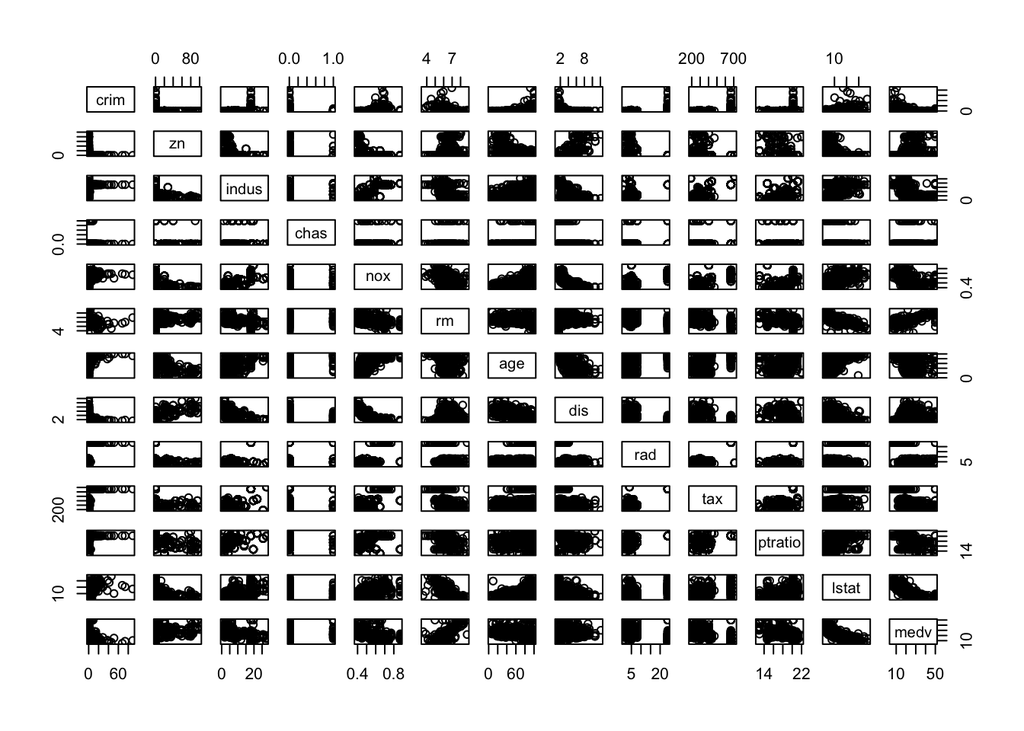

    ```r
    pairs(Boston)
    ```

    *Looks to be a negative correlation between `lstat` & `medv`, `dis` & `nox`; positive correlation between `medv` & `rm`, `age` & `nox`. Most `crim` values are concentrated on the lower end of values, and higher values largely exist at the upper end of `age`.`rm` values are largely concentrated around the central values. Big gap in `rad` & `tax` values.*
    3. Are any of the predictors associated with per capita crime rate? If so, explain the relationship?

       *It looks like higher crime values largely exist when `chas` is 0; at the lower `dis`, `medv`, `zn` values; and at the higher `age`, `rad`, `tax` values.*
    4. Do any of the census tracts of Boston appear to have particularly high crime rates? Tax rates? Pupil-teacher ratios? Comment on the range of each predictor.

    ```r
    apply(Boston[c("crim", "tax", "ptratio")], 2, range)
    ```

    ```
    ##          crim tax ptratio
    ## [1,]  0.00632 187    12.6
    ## [2,] 88.97620 711    22.0
    ```

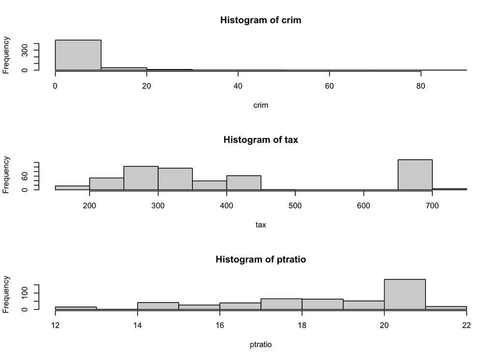

    ```r
    par(mfrow = c(3, 1))
    hist(crim, breaks=10)
    hist(tax, breaks=10)
    hist(ptratio, breaks=10)
    ```

    *Crime rates are largely very low, but there are a handful above 50. Tax rates also stay toward lower values though a number exist over 600 with a big gap in the middle of the range. Most tracts have ptratios above 18 or so.*
    5. How many of the census tracts in the data set bound the Charles river?

    ```r
    sum(chas)
    ```

    ```
    ## [1] 35
    ```

    6. What is the median pupil-teacher ratio among the towns in this data set?

    ```r
    median(ptratio)
    ```

    ```
    ## [1] 19.05
    ```

    7. Which census tract of Boston has lowest median value of owner-occupied homes? What are the values of the other predictors for that census tract, and how do those values compare to the overall ranges for those predictors? Comment on your findings.

    ```r
    Boston_medv <- subset(Boston, medv == min(medv))
    Boston_medv
    ```

    ```
    ##        crim zn indus chas   nox    rm age    dis rad tax ptratio lstat medv
    ## 399 38.3518  0  18.1    0 0.693 5.453 100 1.4896  24 666    20.2 30.59    5
    ## 406 67.9208  0  18.1    0 0.693 5.683 100 1.4254  24 666    20.2 22.98    5
    ```

    ```r
    sum(rm > 7)
    ```

    ```
    ## [1] 64
    ```

    ```r
    sum(rm > 8)
    ```

    ```
    ## [1] 13
    ```

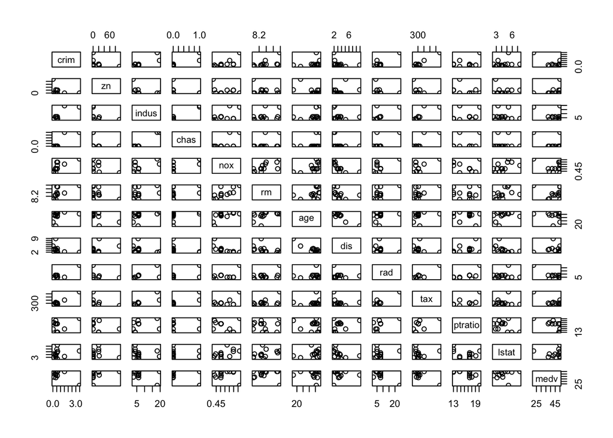

    ```r
    Boston_rm <- subset(Boston, rm > 8)
    pairs(Boston_rm)
    ```